# Predicting Iris species

13/9/2020

## The database

I wanted to make and app where the user can select the values for some flower measurements and the app returns a predicted species.

For this task I fit two models with the Iris dataset available in R. Here the first values:

```
  Sepal.Length Sepal.Width Petal.Length Petal.Width Species
1          5.1         3.5          1.4         0.2  setosa
2          4.9         3.0          1.4         0.2  setosa
3          4.7         3.2          1.3         0.2  setosa
4          4.6         3.1          1.5         0.2  setosa
5          5.0         3.6          1.4         0.2  setosa
6          5.4         3.9          1.7         0.4  setosa
```

## The Plots

I provided to the user a visualization of the data, because it is important to have in mind how is the data distributed. I also add a purple point for the values selected by the user in the sidebar panel.

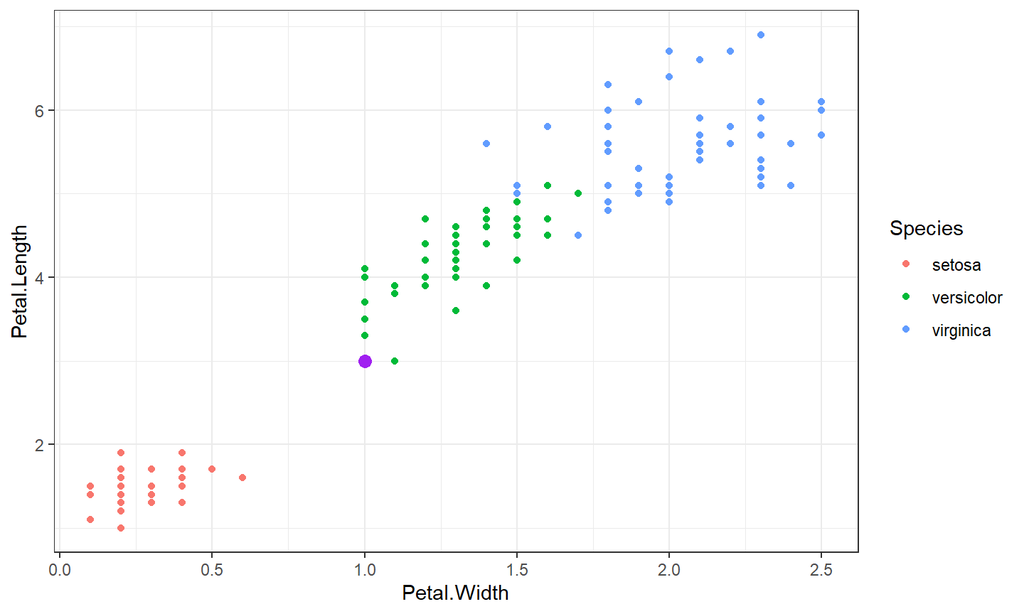

[output not shown]

[output not shown]

## Linear discriminant analysis

Using the `caret` package and creating data partition (p=0.7) for training and testing datasets, I fitted a linear discriminant analysis (lda) model and predict the species for the measures selected by the user. I also provided the accuracy of the model when predicting the testing dataset:

```
      Accuracy          Kappa  AccuracyLower  AccuracyUpper   AccuracyNull
  9.333333e-01   9.000000e-01   8.173155e-01   9.860349e-01   3.555556e-01
AccuracyPValue  McnemarPValue
  5.425807e-16            NaN
```